# IBD meta-analysis metadata processing

## Organization of metadata processing files

The metadata processing is organized as follows

- **sample2project.txt** - contains infromation about every sample in the collection, with the following columns (without the names in the file).
  - *GID* - GP identifier for the sample
  - *StoolID* - stool sample identifier
  - *OriginalID* - sample identifier in the original study (will be used to connect to original study metadata)
  - *DonorID* - donor identifier in the original study
  - *SequencingRun* - sequencing run identifier
  - *Technology* - sequencing technology used for the samples (possible values: 16S, WMS, RNA)
  - *Project* - project name
- **sample2project_common.txt** and **sample2project_common.rds** - same as above, but updated with sample metadata that is common between studies. These files are created by script **merge_annotations.r**
- **raw/** - directory containing raw annotation files whatever format they might be in.
- **processed/** - directory containing the processed files.
  - There will be two sample description files for every project. (XXX will be project name)
    - **XXX_common.txt** and corresponding **.rds** - a file in a tab separated format with header, listing all the common variables that must be included from every project.
      - *Project*
      - *DonorID*
      - *OriginalID* or *GID* - to be able to merge with other tables
      - *Location* - sample location (Possible values: Stool, …)
      - *Diagnosis* - diagnosis (Possible values: UC, IC, CD, Control)
      - *Gender* - (Possible values: Female, Male)
      - *Age*
    - **XXX_special.txt** and corresponding **.rds** - a file in a tab separated format with header, listing all the features specifically available for this project. Following variables are needed in every file.
      - *Project*
      - *DonorID*
      - *OriginalID* or *GID*
  - **metadata.RData** - one RData object that allows to include all metadata at once
- **scripts/** - directory for data munging scripts.
  - **project_XXX.r** - project based data processing scripts. There should be one for every project turning the metadata in `raw/` to processed tables in `processed/`
  - **combine_metadata.r** - onescript to update metadata.RData and other overview tables based on available project based metadata tables.
- **update.r** - master script to re-run all the the project scripts, combine metadata and reknit this document to update the descriptions

## Overview of the dataset

### Sample numbers and projects

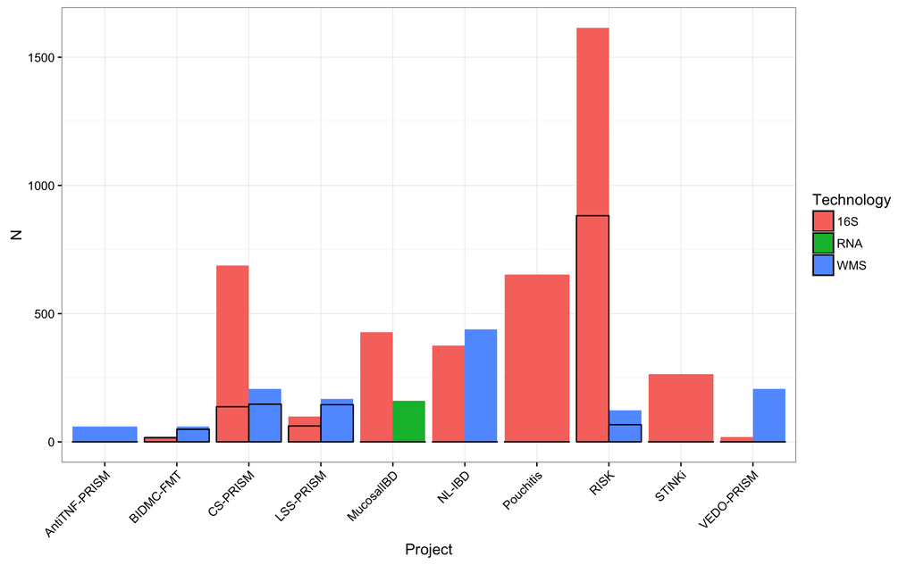

### Summary of common metadata

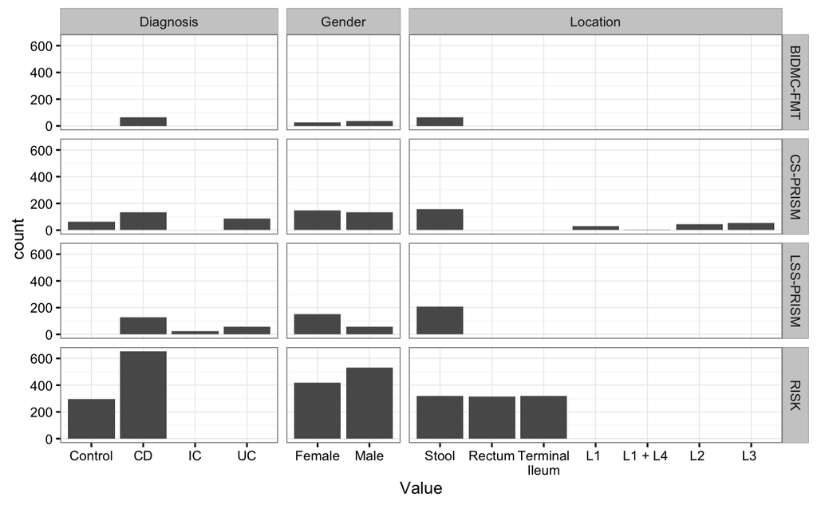

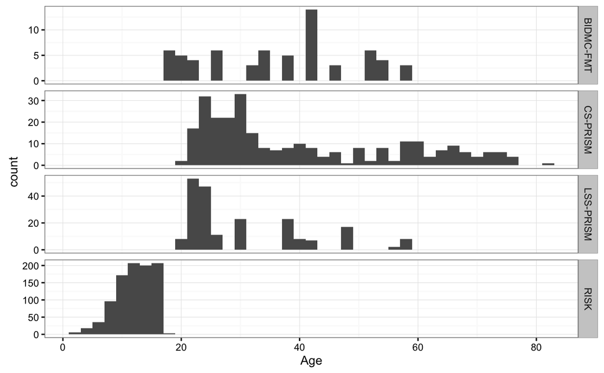

### Other available metadata

```
################## BIDMC-FMT ####################
 Antibiotics Immunosuppressants Steroids DiseaseLocation
 No :30      No :43             No:49    L2 : 2
 Yes:19      Yes: 6                      L2 :18
                                         L3 :15
                                         L3 :14


################## CS-PRISM ####################
 AntiDiarrhoea Mesalamine Antibiotics Steroids   Immunosuppressants Supplements FecalCalprotectin
     : 0           :  0       :  0        :  0       : 0                :  0    Min.   :  0.6649
 No  :91       No  :108   No  :133    No  :121   No  :99            No  :140    1st Qu.: 17.0851
 Yes : 2       Yes : 45   Yes : 19    Yes : 32   Yes :56            Yes : 13    Median : 79.3310
 NA's:63       NA's:  3   NA's:  4    NA's:  3   NA's: 1            NA's:  3    Mean   :112.0667
                                                                                3rd Qu.:213.1055
                                                                                Max.   :277.1280
                                                                                NA's   :63


################## LSS-PRISM ####################
    LSSMonth             SmokingStatus      HBI         FecalCalprotectin
 Min.   : 1.000   Current_smoker:  7   Min.   : 0.000   Min.   :   0.00
 1st Qu.: 3.750   Former_smoker : 24   1st Qu.: 0.000   1st Qu.:  18.16
 Median : 6.000   Never_smoked  :141   Median : 1.000   Median :  45.30
 Mean   : 6.267                        Mean   : 1.831   Mean   : 122.96
 3rd Qu.: 9.000                        3rd Qu.: 3.000   3rd Qu.: 172.56
 Max.   :14.000                        Max.   :11.000   Max.   :1322.00
                                       NA's   :89


################## RISK ####################
 Antibiotics     PCDAI              Race           Ulcering
 No :967     Min.   : 0.00   african  : 83   noulcering:714
 Yes: 73     1st Qu.:20.00   caucasian:749   ulcering  :326
             Median :30.00   other    :208
             Mean   :31.84
             3rd Qu.:42.50
             Max.   :82.50
             NA's   :355
```

### Browse sample2project

[output not shown]

|  | GID | StoolID | OriginalID | DonorID | SequencingRun | Technology | Project | Location | Diagnosis | Gender | Age |
| --- | --- | --- | --- | --- | --- | --- | --- | --- | --- | --- | --- |
| 1 | G47391 | SM-3U16K | NP328-bx | NP328 | PDO-2016 | 16S | MucosalIBD |  |  |  |  |
| 2 | G47392 | SM-3U16L | NP330-bx | NP330 | PDO-2016 | 16S | MucosalIBD |  |  |  |  |
| 3 | G47393 | SM-3U16M | NP331-bx | NP331 | PDO-2016 | 16S | MucosalIBD |  |  |  |  |
| 4 | G47394 | SM-3U16N | NP332-bx | NP332 | PDO-2016 | 16S | MucosalIBD |  |  |  |  |
| 5 | G47395 | SM-3U16O | NP333-bx | NP333 | PDO-2016 | 16S | MucosalIBD |  |  |  |  |
| 6 | G47396 | SM-3U16P | NP334-bx | NP334 | PDO-2016 | 16S | MucosalIBD |  |  |  |  |
| 7 | G47397 | SM-3U16Q | NP335-bx | NP335 | PDO-2016 | 16S | MucosalIBD |  |  |  |  |
| 8 | G47398 | SM-3U16R | NP336-bx | NP336 | PDO-2016 | 16S | MucosalIBD |  |  |  |  |
| 9 | G47399 | SM-3U16S | NP337-bx | NP337 | PDO-2016 | 16S | MucosalIBD |  |  |  |  |
| 10 | G47400 | SM-3U16T | NP339-bx | NP339 | PDO-2016 | 16S | MucosalIBD |  |  |  |  |

[output cut: 5572 more lines]